# Worked-out examples

Richel Bilderbeek

2017-05-10

This document shows some work-out examples.

These worked-out examples show:

- the error if protractedness is absent
- the error if protractedness strong
- comparing these errors
- the error if protractedness is absent for multiple replicates
- the error if protractedness is strong for multiple replicates
- comparing these errors

## Workflow

Every experiment has the following steps:

- Starting up
- Creating parameter files
- Per parameter file:
- Simulate one incipient species tree per parameter file
- Once or more often, sample unique species from an incipient species tree
- Per sampled species tree, add an outgroup
- Simulate one or more alignments per species tree
- Once or more often, let BEAST2 infer a posterior per alignment
- Compare original, sampled species tree, to the posterior
- Per two parameter files:
- Compare original, sampled species tree, to the posterior

## Starting up

We will need to load some libraries:

```r
library(ape)
library(wiritttea)
library(ggplot2)
library(nLTT)
library(phangorn)
options(warn = 2)
```

We also set the resolution of our analysis:

```r
dt <- 0.001
```

I use `0.1` while developing code, `0.001` for a decent analysis.

## Creating parameter files

This worked-out example will show:

- the error if protractedness is absent
- the error if protractedness strong
- comparing these errors
- the error if protractedness is absent for multiple replicates
- the error if protractedness is strong for multiple replicates
- comparing these errors

For that, I will create four parameter files:

- `analyse_toy_examples_1.RDa`: protractedness is absent
- `analyse_toy_examples_2.RDa`: protractedness strong
- `analyse_toy_examples_3.RDa`: protractedness is absent for multiple replicates
- `analyse_toy_examples_4.RDa`: protractedness is strong for multiple replicates

Here the parameter files are created with the desired parameters:

```r
filenames <- paste0("analyse_toy_examples_", seq(1, 4), ".RDa")
wiritttes::create_test_parameter_files(filenames = filenames)
```

- `analyse_toy_examples_1.RDa`: protractedness is absent, thus speciation completion rate is high, in this case `1.0e6`
- `analyse_toy_examples_2.RDa`: protractedness strong, thus speciation completion rate is low, inde this case `1.0e-1`
- `analyse_toy_examples_3.RDa`: protractedness is absent for multiple replicates, thus number of sampled species trees, alignments per species trees, and BEAST2 runs are all 2
- `analyse_toy_examples_4.RDa`: protractedness is strong for multiple replicates, thus number of sampled species trees, alignments per species trees, and BEAST2 runs are all 2

Here the parameters are shown in a nicer format:

```r
knitr::kable(t(head(read_collected_parameters())))
```

|  | toy_example_1.RDa | toy_example_2.RDa | toy_example_3.RDa | toy_example_4.RDa |
| --- | --- | --- | --- | --- |
| rng_seed | 1e+00 | 2e+00 | 3e+00 | 4e+00 |
| sirg | 5e-01 | 5e-01 | 5e-01 | 5e-01 |
| siri | 5e-01 | 5e-01 | 5e-01 | 5e-01 |
| scr | 1e+06 | 1e-01 | 1e+06 | 1e-01 |
| erg | 1e-01 | 1e-01 | 1e-01 | 1e-01 |
| eri | 1e-01 | 1e-01 | 1e-01 | 1e-01 |
| age | 5e+00 | 5e+00 | 5e+00 | 5e+00 |
| mutation_rate | 1e-02 | 1e-02 | 1e-02 | 1e-02 |
| n_alignments | 1e+00 | 1e+00 | 2e+00 | 2e+00 |
| sequence_length | 1e+03 | 1e+03 | 1e+03 | 1e+03 |
| nspp | 1e+01 | 1e+01 | 1e+01 | 1e+01 |
| n_beast_runs | 1e+00 | 1e+00 | 2e+00 | 2e+00 |

The parameter settings used in this example are identical, except for their speciation completion rate and number of replicates.

The experimental setup of this research has multiple steps, which we will follow closely here.

These worked-out examples show the data produced in its raw form and does not care too much about aesthetics.

## Example 1: Weak protractedness

This example answers the question: what is the base level error of the analyses in this research?

The base level error can be obtained by using parameters for a constant-rate birth-death model. All tools used assume this model, but there will be noise (thus error) added in the process.

The parameter settings of example 1 have a high speciation completion rate , which makes the constant-rate protracted speciation model fall back to a constant-rate birth-death model, as incipient species become good species (close to) instantaneously.

### Simulate one incipient species tree per parameter file

Here we simulate the ‘true’ incipient species tree:

```r
filename <- filenames[1]
testit::assert(wiritttes::is_valid_file(filename))
wiritttes::add_pbd_output(filename)
```

This is how the incipient species tree looks like:

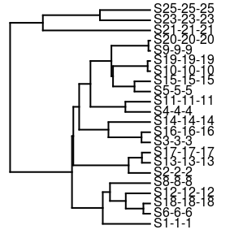

```r
colors <- stats::setNames(c("gray", "black"), c("i", "g"))
testit::assert(
  length(
    wiritttes::read_file(filename)$pbd_output$igtree.extant$tip.label
  ) > 0
)
phytools::plotSimmap(
  wiritttes::read_file(filename)$pbd_output$igtree.extant,
  colors = colors
)
```

```r
n_taxa_istree <- length(
  wiritttes::read_file(filename)$pbd_output$igtree.extant$tip.label)
```

There are 22 taxa in the incipient species tree. All taxa are good species, so the edges of the phylogeny have only one color. The taxon labels are S[genus]-[species]-[sub-species]’.

Now, we plot the nLTT plot of this phylogeny:

[figure not shown]

```r
nltt_values <- get_nltt_values(
  phylogenies = list(wiritttes::read_file(filename)$pbd_output$tree),
  dt = 0.001
)
qplot(
  t, nltt, data = nltt_values, geom = "blank", ylim = c(0, 1),
  main = "Example #1"
) + stat_summary(
  fun.data = "mean_cl_boot", color = "red", geom = "smooth"
)
```

Note that `get_nltt_values` is supplied a list of the one incipient species tree. This is because `get_nltt_values` works on a list of phylogenies.

### Once or more often, sample unique species from an incipient species tree. Also add an outgroup

From that incipient species tree, we create a species tree by sampling one individual per incipient species. Because speciation is for a constant-rate birth death model, there exist no multiple individuals per species. To being able to root our phylogenies in later steps, an outgroup is added as well.

```r
wiritttes::add_species_trees(filename)
```

Here we observe the sample species tree:

```r
n_taxa_sstree <- length(
  wiritttes::get_species_tree_by_index(
    wiritttes::read_file(filename), 1)$tip.label
  )
```

In the sampled species tree, there are 22 taxa, where in the incipient species tree we had 22 taxa.

Note that in example #3, there will be multiple sampled species trees.

### Simulate one or more alignments per species tree

Knowing the evolutionary distances between species, DNA sequence alignments can be simulated fitting the species tree with outgroup. To do so, the parameters for sequence length and mutation rate are used.

Here we simulate one DNA sequence on our one sampled species tree with outgroup:

```r
wiritttes::add_alignments(filename)
```

Note that this research assumes a simple Jukes-Cantor model, and does so as well in later steps.

Let’s see the alignment:

```r
n_taxa_alignment <- length(
  labels(
    wiritttes::get_alignment_by_index(
      file = wiritttes::read_file(filename),
      i = 1
    )
  )
)
```

In the alignment, there are 22 taxa, where in the sampled species tree, there are 22 taxa.

### Once or more often, let BEAST2 infer a posterior per alignment

With BEAST2 we can now obtain a posterior. A posterior consists of a representative sample of all possible trees (and parameter estimates), yet with more probable trees being present more often.

Here we let BEAST2 do so:

```r
wiritttes::add_posteriors(filename)
```

```
## [1] 2
```

After running BEAST2 on our DNA sequence, the full posterior must be verified to be eligible for further analysis. Using Tracer, we can open the .log file generated by BEAST2, which has to be done manually.

It can be seen that the values for ESS (Effective Sample Size) are above 200 and that the trace log shows a well-mixed chain. An ESS of 200 is used as a minimum in this research.

A posterior contains many phylogenies.

```r
phylogenies <- wiritttes::get_posteriors(
  wiritttes::read_file(filename))[[1]][[1]]$trees
# To get the densiTree function working,
# phylogenies must be of class multiphylo
class(phylogenies) <- "multiPhylo"
```

Then, these posterior trees are plotted:

```r
densiTree(
  phylogenies,
  type = "cladogram",
  alpha = 1/length(phylogenies)
)
```

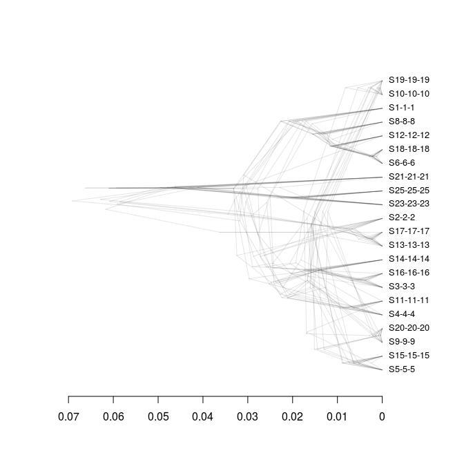

From this plot, it can be seen which phylogeny configurations pop up most in the posterior.

### Compare original, sampled species tree, to the posterior

Now that the full posterior is assumed to be correct, first, I will now highlight one of its posterior states, before going back to the full picture.

This random tree may be very different by chance, as unlikely trees are present, yet in low abundances.

The original sampled tree is very probably different from this random posterior tree.

How different then?

There are multiple ways to quantify this:

- The gamma statistic
- The nLTT statistic

#### The gamma statistic

The gamma value is a summary statistic described in [2]

First, I collect the gamma statistics from the species tree(s) with outgroup(s):

```r
true_gamma_statistics <- collect_file_stree_gammas(filename = filename)
knitr::kable(head(true_gamma_statistics))
```

| sti | gamma_stat |
| --- | --- |
| 1 | 0.005813 |
| 2 | 0.005813 |

Then, I collect the gamma statistics from the posterior(s):

```r
posterior_gamma_statistics <- collect_file_posterior_gammas(
  filename = filename
)
knitr::kable(head(posterior_gamma_statistics))
```

| sti | ai | pi | si | gamma_stat |
| --- | --- | --- | --- | --- |
| 1 | 1 | 1 | 1 | -1.4636742 |
| 1 | 1 | 1 | 2 | 0.3023258 |
| 1 | 1 | 1 | 3 | 0.2786837 |
| 1 | 1 | 1 | 4 | 0.2775712 |
| 1 | 1 | 1 | 5 | 0.2398863 |
| 1 | 1 | 1 | 6 | 0.1298827 |

#### The nLTT statistic

The nLTT value is a summary statistic described in [1]

First, I collect the nLTT values from the species tree(s) with outgroup(s):

```r
true_nltt_values <- collect_file_stree_nltts(filename = filename, dt = dt)
knitr::kable(head(true_nltt_values))
```

| sti | t | nltt |
| --- | --- | --- |
| 1 | 0.000 | 0.0454545 |
| 1 | 0.001 | 0.0909091 |
| 1 | 0.002 | 0.0909091 |
| 1 | 0.003 | 0.0909091 |
| 1 | 0.004 | 0.0909091 |
| 1 | 0.005 | 0.0909091 |

Then, I collect the nLTT values from the posterior(s):

```r
posterior_nltt_values <- collect_file_posterior_nltts(
  filename = filename, dt = dt
)
knitr::kable(head(posterior_nltt_values))
```

| sti | ai | pi | si | t | nltt |
| --- | --- | --- | --- | --- | --- |
| 1 | 1 | 1 | 1 | 0.000 | 0.0909091 |
| 1 | 1 | 1 | 1 | 0.001 | 0.0909091 |
| 1 | 1 | 1 | 1 | 0.002 | 0.0909091 |
| 1 | 1 | 1 | 1 | 0.003 | 0.0909091 |
| 1 | 1 | 1 | 1 | 0.004 | 0.0909091 |
| 1 | 1 | 1 | 1 | 0.005 | 0.0909091 |

Last, I plot both of these:

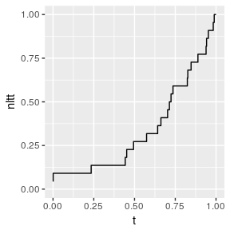

```r
ggplot2::ggplot(
  data = posterior_nltt_values,
  ggplot2::aes(t, nltt),
  main = "nLTT plots"
) + ggplot2::geom_point(
  color = "transparent"
) + ggplot2::scale_x_continuous(
  limits = c(0, 1)
) + ggplot2::scale_y_continuous(
  limits = c(0, 1)
) + ggplot2::stat_summary(
  fun.data = "mean_cl_boot", size = 0.5, lty = "dashed",
  color = I("black"), geom = "smooth"
) + ggplot2::geom_step(
  data = true_nltt_values,
  ggplot2::aes(t, nltt)
)
```

How do we interpret these results? Well, even *if* we follow all assumptions, this will be standard errors we will make; this is the minimal level of imperfection.

Note that the error is not quantified only visualized. TODO: Issue #21

## Example 2: Strong protractedness

This example answers the question: how do the analyses of this research look like for strong protractedness?

The pipeline is identical, except one parameter is changed: the speciation completion rate is set to a low value.

### Simulate one incipient species tree per parameter file

Here we simulate the ‘true’ incipient species tree:

```r
filename <- filenames[2]
testit::assert(wiritttes::is_valid_file(filename))
wiritttes::add_pbd_output(filename)
```

This is how the incipient species tree looks like:

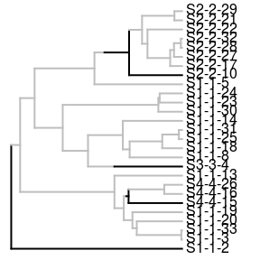

```r
colors <- stats::setNames(c("gray", "black"), c("i", "g"))
testit::assert(length(wiritttes::read_file(filename)$pbd_output$igtree.extant$tip.label) > 0)
phytools::plotSimmap(
  wiritttes::read_file(filename)$pbd_output$igtree.extant,
  colors = colors
)
```

Now, we plot the nLTT plot of this phylogeny:

[figure not shown]

```r
nltt_values <- get_nltt_values(
  phylogenies = list(wiritttes::read_file(filename)$pbd_output$tree),
  dt = 0.001
)
qplot(
  t, nltt, data = nltt_values, geom = "blank", ylim = c(0, 1),
  main = "Example #2 incipient species tree"
) + stat_summary(
  fun.data = "mean_cl_boot", color = "red", geom = "smooth"
)
```

### Once or more often, sample unique species from an incipient species tree. Also add an outgroup

```r
wiritttes::add_species_trees(filename)
```

Note that in example #4, there will be multiple sampled species trees.

### Simulate one or more alignments per species tree

Here we simulate one DNA sequence on our one sampled species tree with outgroup:

```r
wiritttes::add_alignments(filename)
```

### Once or more often, let BEAST2 infer a posterior per alignment

Here we let BEAST2 infer a posterior:

```r
wiritttes::add_posteriors(filename)
```

```
## [1] 2
```

A posterior contains many phylogenies. To visualize these, they are extracted from a `.trees` file here:

```r
phylogenies <- wiritttes::get_posteriors(wiritttes::read_file(filename))[[1]][[1]]$trees
# To get the densiTree function working, phylogenies must be of class multiphylo
class(phylogenies) <- "multiPhylo"
```

Then, these posterior trees are plotted:

```r
densiTree(
  phylogenies,
  type = "cladogram",
  alpha = 1/length(phylogenies)
)
```

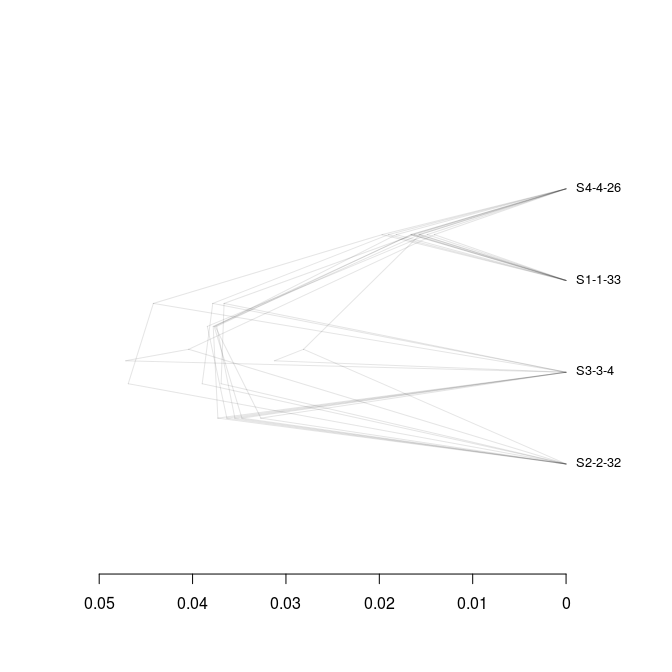

From this plot, it can be seen which phylogeny configurations pop up most in the posterior.

### Compare original, sampled species tree, to the posterior

#### The nLTT statistic

The nLTT value is a summary statistic described in [1]

First, I collect the nLTT values from the species tree(s) with outgroup(s):

```r
true_nltt_values <- collect_file_stree_nltts(filename = filename, dt = dt)
knitr::kable(head(true_nltt_values))
```

| sti | t | nltt |
| --- | --- | --- |
| 1 | 0.000 | 0.5 |
| 1 | 0.001 | 0.5 |
| 1 | 0.002 | 0.5 |
| 1 | 0.003 | 0.5 |
| 1 | 0.004 | 0.5 |
| 1 | 0.005 | 0.5 |

Then, I collect the nLTT values from the posterior(s):

```r
posterior_nltt_values <- collect_file_posterior_nltts(
  filename = filename, dt = dt
)
knitr::kable(head(posterior_nltt_values))
```

| sti | ai | pi | si | t | nltt |
| --- | --- | --- | --- | --- | --- |
| 1 | 1 | 1 | 1 | 0.000 | 0.5 |
| 1 | 1 | 1 | 1 | 0.001 | 0.5 |
| 1 | 1 | 1 | 1 | 0.002 | 0.5 |
| 1 | 1 | 1 | 1 | 0.003 | 0.5 |
| 1 | 1 | 1 | 1 | 0.004 | 0.5 |
| 1 | 1 | 1 | 1 | 0.005 | 0.5 |

Last, I plot both of these:

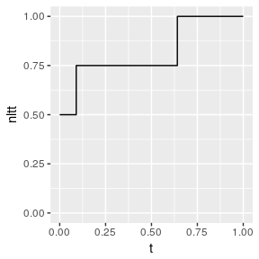

```r
ggplot2::ggplot(
  data = posterior_nltt_values,
  ggplot2::aes(t, nltt),
  main = "nLTT plots"
) + ggplot2::geom_point(
  color = "transparent"
) + ggplot2::scale_x_continuous(
  limits = c(0, 1)
) + ggplot2::scale_y_continuous(
  limits = c(0, 1)
) + ggplot2::stat_summary(
  fun.data = "mean_cl_boot", size = 0.5, lty = "dashed",
  color = I("black"), geom = "smooth"
) + ggplot2::geom_step(
  data = true_nltt_values,
  ggplot2::aes(t, nltt)
)
```

Note that the error is not quantified only visualized. TODO: Issue #21

We cannot draw concusions yet:

- the number of branches is too little
- the number of replicates is too little

## Comparing example 1 and 2

In the next examples, we add replicates to the data.

## Example 3: Weak protractedness with replicates

Doing the rest:

```r
wiritttes::do_simulation(filenames[3])
```

```
## [1] 8
```

```r
wiritttes::do_simulation(filenames[4])
```

```
## [1] 8
```

This example is an extension of the examples 1, with the differences that:

- From the (same) incipient species tree, multiple species trees are sampled
- Per species tree, multiple DNA alignments are simulated
- Per DNA alignment, multiple BEAST2 runs are performed

### Species tree

It has little use to sample multiple species trees from an incipient species tree, as these are identical for instant speciation models. In this example, we do sample a species trees twice from the true incipient species tree. This results in two identical species trees.

### Alignment

From these (in this case identical) species trees, multiple alignments can be simulated. In this example, for every species tree, there are two alignments simulated. Because in this example, there are two species sampled, and every species tree has two alignments simulated, this results in four alignments.

Each alignment is different.

### Posterior

In this example, for each alignment, we do two BEAST2 runs, instead of one. It is expected (or: it should be the case) that both runs create a similar posterior. Because this example has 2 species trees, 2 alignments per species tree and 2 BEAST2 runs per alignment, 8 different-yet-similar posteriors are expected.

### Do posteriors contain paraphylies?

Never, which is expected, as there is no protractedness

### nLTT plots of BEAST runs

nLTT plots of alignments

### Do the different alignments matter?

The different alignments do matter.

### nLTT plots of species trees

Do the different species tree matter?

A bit.

## Example 4: Strong protractedness with replicates

This example is an extension of the previous examples, with the differences that:

- From the (same) incipient species tree, multiple species trees are sampled
- Per species tree, multiple DNA alignments are simulated
- Per DNA alignment, multiple BEAST2 runs are performed

### Alignment

Each alignment is different.

### Posterior

In this example, for each alignment, we do two BEAST2 runs, instead of one. It is expected (or: it should be the case) that both runs create a similar posterior. Because this example has 2 species trees, 2 alignments per species tree and 2 BEAST2 runs per alignment, 8 different-yet-similar posteriors are expected.

Last tree

### Do posteriors contain paraphylies?

Never BEAST2 creates monophyletic trees.

### nLTT plots of alignments

Do the different alignments matter?

The different alignments do matter.

### nLTT plots of species trees

Do the different species tree matter?

A bit.

## Comparing example 3 and 4

Because of the number of repeats, there are more data points, as all are lumped together.

## References

- [1] Janzen, Thijs, Sebastian Höhna, and Rampal S. Etienne. “Approximate Bayesian Computation of diversification rates from molecular phylogenies: introducing a new efficient summary statistic, the nLTT.” Methods in Ecology and Evolution 6.5 (2015): 566-575.
- [2] Pybus, Oliver G., and Paul H. Harvey. “Testing macro–evolutionary models using incomplete molecular phylogenies.” Proceedings of the Royal Society of London B: Biological Sciences 267.1459 (2000): 2267-2272.

## Cleaning up

```r
file.remove(filenames)
```

```
## [1] TRUE TRUE TRUE TRUE
```